# Basics of HTML and CSS MY472 Week 4

October 22, 2019

## Scraping the web

## Scraping the web: what?

An increasing amount of data is available on the web:

- Speeches, sentences, biographical information…
- Social media data, newspaper articles, press releases…
- Geographic information, conflict data…

These datasets are often provided in an **unstructured format**.

**Web scraping** is the process of extracting this information automatically and transforming it into a **structured dataset.**

## Scraping the web: Why?

Copy & pasting is time-consuming, boring, prone to errors, and impractical for large datasets

**In contrast, automated web scraping:**

1. Scales well for large datasets
2. Is reproducible
3. Involved adaptable techniques
4. Facilitates detecting and fixing errors

**When to scrape?**

1. Trade-off between your time today and your time in the future. **Invest in your future self!**
2. Computer time is cheap; human time is expensive

## Scraping the web: two approaches

### **Two different approaches:**

1. **Screen scraping**: extract data from source code of website, with html parser and/or regular expressions
   - `rvest` package in R
2. **Web APIs** (application programming interfaces): a set of structured http requests that return JSON or XML data
   - `httr` package to construct API requests
   - Packages specific to each API: [weatherData](https://cran.r-project.org/web/packages/weatherData/index.html), [WDI](https://cran.r-project.org/web/packages/WDI/index.html), [Rfacebook](https://cran.r-project.org/web/packages/Rfacebook/index.html),
     - Check CRAN Task View on [Web Technologies and Services](https://cran.r-project.org/web/views/WebTechnologies.html) for examples
   - More on APIs on Week 7

## The Internet, how it works

## Client-server model

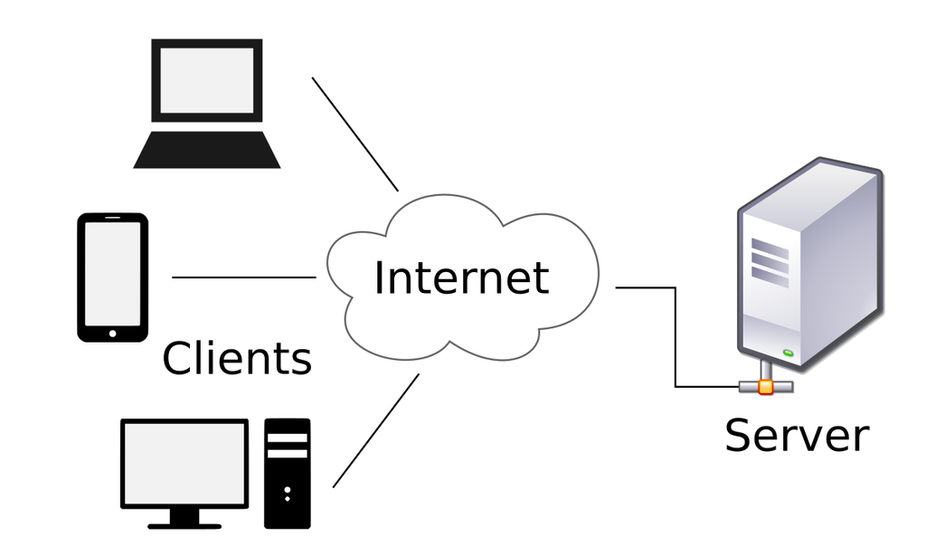

## Client-server model

- Client: user computer; tablet; phone; software application; etc.
- Server: Jupyter server on Fabian; mail server; file server; web server; etc.
1. Client make requrests to the server
   - Depending on what you want to get, the request might be
     - HTTP
     - HTTPS
     - SMTP
     - FTP
2. Server returns something

## In the case of HTTP request and response

From [StackOverflow](https://stackoverflow.com/questions/4109689/how-does-a-client-browser-generate-a-request-to-be-sent-to-a-server)

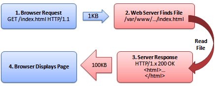

## Simple example: MY472 website

Let’s see a very simple example of https://lse-my472.github.io

[figure not shown]

## Simple example: MY472 website

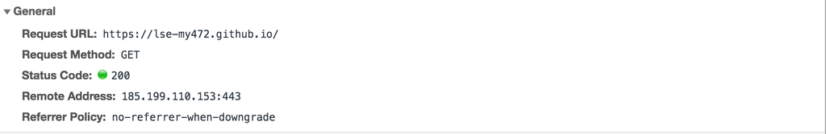

## Simple example: Request headers

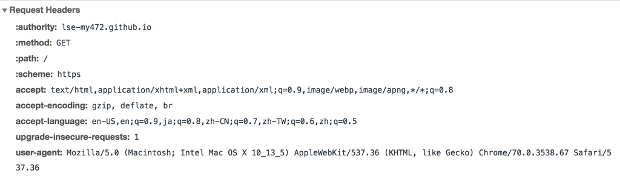

## Simple example: Response headers

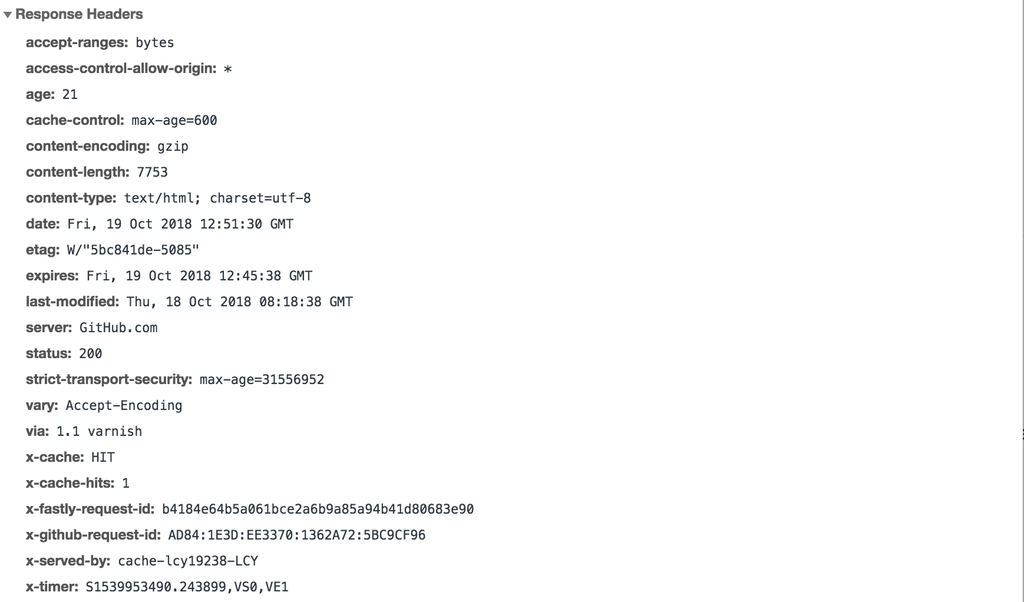

## Simple example: Reponse content

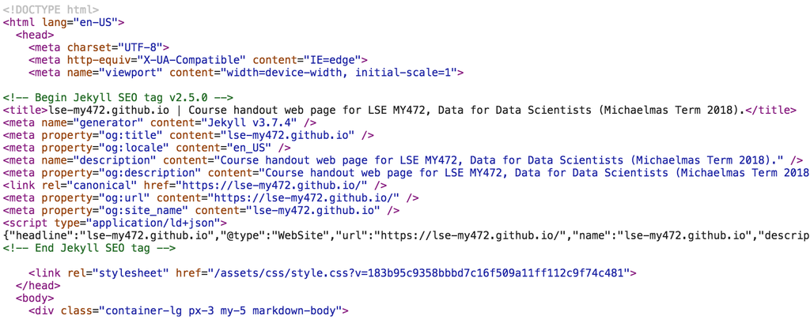

## HTML and CSS

## HTML

**HTML: Hyper-Text Markup Language**

- HTML displays mostly **static** content
- Many contents of dynamic webpages cannot be found anywhere in html
  - Example: Google Maps
- Understanding what’s static and what’s dynamic in a webpage is a crucial first step for web scraping

## A simplest html file

https://www.w3schools.com/html/tryit.asp?filename=tryhtml_intro

```html
<!DOCTYPE html>
<html>
<head>
    <title>Page Title</title>
</head>
<body>
    <h1>My First Heading</h1>
    <p>My first paragraph.</p>
</body>
</html>
```

## Another simple html file

```html
<!DOCTYPE html>
<html>
<head>
    <title>My Title</title>
</head>
<body>
    <h1>My Header</h1>
    <a href="http://kenbenoit.net">My link</a>
</body>
</html>
```

## HTML Structure

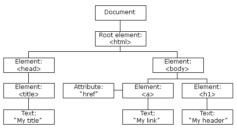

## Beyond HTML

1. **Cascading Style Sheets (CSS)** Describes formatting of HTML components, useful for us!

[figure not shown]

2. **Javascript**: adds functionalities to the website (e.g. change content/structure after website has been loaded)

## Webscraping, three main scenarios

## Scinario 1: Data in table format

[figure not shown]

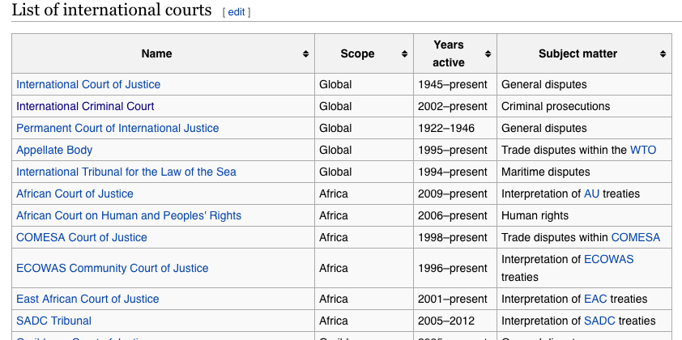

## Scinario 2: Data in unstructured format

[figure not shown]

www.ipaidabribe.com/reports/paid

## Scinario 3: hidden behind web forms

[figure not shown]

## Three main scenarios

1. Data in *table* format
   - Automatic extraction with **rvest**
2. Data in *unstructured* format
   - Element identification
     - `selectorGadget`
     - *Inspect* in browser
   - Identify the target with *CSS* or *xpath* selector
   - Automatic extraction with **rvest**
3. Data hidden *behind web forms*
   - Automation of web browser behavior with **RSelenium**

## CSS Selector

We use it to select particular element from a webpage:

- selecting by tag-name
  - example html code: `<h3>This is the main item</h3>`
  - selector: `h3`
- selecting by class
  - example html code: `<div class = 'itemdisplay'>This is the main item</div>`
  - selector: `.itemdisplay`
- selecting by id
  - example html code: `<div id = 'maintitle'>my main title</div>`
  - selector: `#maintitle`

## CSS Selector

- selecting by tag structure
  - example html code: (link inside `div` tag)  
    `<div><a href = 'https://www.google.com'>Google Link</a></div>`
    - selector: `div a`

Reference: https://www.w3schools.com/cssref/css_selectors.asp

A similar but more powerful selector is **xpath**

## The rules of the game

1. Respect the hosting site’s wishes:
   - Check if an API exists or if data are available for download
   - Keep in mind where data comes from and give credit (and respect copyright if you want to republish the data!)
   - Some websites *disallow* scrapers on `robots.txt` file
2. Limit your bandwidth use:
   - Wait one or two seconds after each hit
   - Scrape only what you need, and just once
3. When using APIs, read documentation
   - Is there a batch download option?
   - Are there any rate limits?
   - Can you share the data?

## A note on code formatting

- The [tidyverse style guide](https://style.tidyverse.org/) is a good set of principles to follow
  - Note: the style guide itself is published in a format called **bookdown** that automatically compiles a book/website/pdf/epub from Rmd sources
- Consider **lintr** (example)
- Works on .R, .Rmd, etc.

## Lab preview

- Part 1: Scraping a table from the website of the UK parliament
- Part 2: Scraping unstructured data from a government petitions website
- More advanced topics follow next week, with APIs in Week 7
- Remedial topics from the [Digital Skills Lab](https://info.lse.ac.uk/current-students/digital-skills-lab)